# Testing objects

We have some objects. This notebook runs them through their paces. We can use this to write a unittest.

Import anything we might need.

```python
import numpy as np
```

Now we can run through the objects. They are:

- Rock: A set of attributes.
- Decor: One element from a legend — describes how to display a Rock.
- Legend: A set of Decors — describes how to display a set of Rocks or a Striplog.
- Interval: One element from a Striplog — consists of a top, base, a description, a Rock, and a source.
- Striplog: A set of Intervals.

We need a lexicon of words to check things against. This is not a class, but maybe it should be...

- Lexicon: A dictionary containing the words and word categories to use for rock descriptions.

## Rock

A set of attributes. All are optional.

```python
from interval import Rock
```

```python
print Rock.__doc__
```

```
    Initialize with a dictionary of properties. You can use any
    properties you want, but the following are recognized by
    the summary() method:

        - lithology: a simple one-word rock type
        - colour, e.g. 'grey'
        - grainsize or range, e.g. 'vf-f'
        - modifier, e.g. 'rippled'
        - quantity, e.g. '35%', or 'stringers'
        - description, e.g. from cuttings

    You can include as many other things as you want, e.g.

        - porosity
        - cementation
        - lithology code
```

```python
r = {'colour': 'grey',
     'grainsize': 'vf-f',
     'lithology': 'sand'}
```

```python
rock = Rock(r)
rock
```

```
Rock(colour='grey', lithology='sand', grainsize='vf-f')
```

```python
type(rock)
```

```
rock.Rock
```

The Rock has a colour:

```python
rock.colour
```

```
'grey'
```

And it has a summary, which is generated from its attributes.

```python
rock.summary()
```

```
'Grey vf-f sand'
```

We can format the summary if we wish:

```python
rock.summary(fmt="%L (%c, %g)")
```

```
'Sand (grey, vf-f)'
```

We can compare rocks with the usual `==` operator, thanks to the `__eq__` method.

```python
rock2 = Rock({'grainsize': 'VF-F',
              'colour': 'Grey',
              'lithology': 'Sand'})
rock == rock2
```

```
True
```

In order to create a Rock object from text, we need a lexicon to compare the text against. The lexicon describes the language we want to extract, and what it means. More on lexicons later.

```python
import json
with open('lexicon.json', 'r') as fp:
    lexicon = json.load(fp)
```

```python
Rock.from_text('Grey fine sandstone.', lexicon)
```

```
Rock(colour='grey', lithology='sandstone', grainsize='fine')
```

## Decor

```python
from legend import Decor

import matplotlib.pyplot as plt
%matplotlib inline
```

A Decor attaches a display style to a Rock.

```python
print Decor.__doc__
```

```
    A single display style. Analogous to 'Rock', a Decor describes how to
    display a given set of Rock properties.

    In general, you will want to use a Legend, which is just a list of
    Decors, and leave the Decors to the Legend.
```

```python
d = {'color': '#86F0B6',
     'rock': rock,
     'width': 3}
decor = Decor(d)
```

```python
decor.colour
```

```
'#86f0b6'
```

```python
decor.rgb
```

```
(134, 240, 182)
```

We can ask for the Rock a Decor represents.

```python
decor.rock
```

```
Rock(colour='grey', lithology='sand', grainsize='vf-f')
```

```python
decor.rock.summary()
```

```
'Grey vf-f sand'
```

```python
decor.plot()
```

[output not shown]

## Legend

```python
from legend import Legend
print Legend.__doc__
```

```
    A look-up table to assist in the conversion of Rocks to
    a plot colour.
```

We'll define a legend in a CSV file. I can't think of a better way for now. It would be easy to make a web form to facilitate this with, for example, a colour picker. It may not be worth it, though; I imagine one would create one and then leave it alone most of the time.

```python
l = """colour, width, rock lithology, rock colour, rock grainsize
#FFFFFF, 0, , ,
#F7E9A6, 3, Sandstone, Grey, VF-F
#FF99CC, 2, Anhydrite, ,
#DBD6BC, 3, Heterolithic, Grey,
#FF4C4A, 2, Volcanic, ,
#86F0B6, 5, Conglomerate, ,
#FF96F6, 2, Halite, ,
#F2FF42, 4, Sandstone, Grey, F-M
#DBC9BC, 3, Heterolithic, Red,
#A68374, 2, Siltstone, Grey,
#A657FA, 3, Dolomite, ,
#FFD073, 4, Sandstone, Red, C-M
#A6D1FF, 3, Limestone, ,
#FFDBBA, 3, Sandstone, Red, VF-F
#FFE040, 4, Sandstone, Grey, C-M
#A1655A, 2, Siltstone, Red,
#363434, 1, Coal, ,
#664A4A, 1, Mudstone, Red,
#666666, 1, Mudstone, Grey, """
```

```python
legend = Legend.from_csv(l)
legend[:5]
```

```
[Decor(width='0.0', colour='#ffffff', rock='colour='', lithology='', grainsize='''),
 Decor(width='3.0', colour='#f7e9a6', rock='colour='grey', lithology='sandstone', grainsize='vf-f''),
 Decor(width='2.0', colour='#ff99cc', rock='colour='', lithology='anhydrite', grainsize='''),
 Decor(width='3.0', colour='#dbd6bc', rock='colour='grey', lithology='heterolithic', grainsize='''),
 Decor(width='2.0', colour='#ff4c4a', rock='colour='', lithology='volcanic', grainsize=''')]
```

We can ask the Legend what colour to use for a given Rock object:

```python
legend.get_colour(rock)
```

```
'#EEEEEE'
```

```python
rock3 = Rock({'colour': 'red',
           'grainsize': 'vf-f',
           'lithology': 'sandstone'})
legend.get_colour(rock3)
```

```
'#ffdbba'
```

Sometimes we also want to use a width for a given lithology:

```python
legend.get_width(rock3)
```

```
3.0
```

We can also ask the legend which Rock is represented by a particular colour.

```python
legend.get_rock('#f7e9a6')
```

```
Rock(colour='grey', lithology='sandstone', grainsize='vf-f')
```

The Legend behaves more or less like a list, so we can index into it:

```python
legend[3].rock
```

```
Rock(colour='grey', lithology='heterolithic', grainsize='')
```

And it can plot itself.

```python
legend.plot()
```

[output not shown]

## Interval

```python
from interval import Interval
print Interval.__doc__
```

```
    Used to represent a lithologic or strigraphic interval, or a single point,
    such as a sample location.

    Initialize with a top (and optional base) and a description and/or
    an ordered list of components, each of which is a Rock.
```

```python
interval = Interval(20, 40, "Grey sandstone.", lexicon=lexicon)
interval
```

```
Interval(top: 20.0, base: 40.0, description: 'Grey sandstone.', components: [Rock(colour='grey', lithology='sandstone')])
```

```python
interval.primary
```

```
Rock(colour='grey', lithology='sandstone')
```

```python
interval.summary()
```

```
'20.0 m of grey sandstone'
```

We can compare intervals, based on their thickness.

```python
interval_2 = Interval(40, 65, "Red sandstone.", lexicon=lexicon)
```

```python
print interval_2 == interval
print interval_2 > interval
print max(interval, interval_2).components
```

```
False
True
[Rock(colour='red', lithology='sandstone')]
```

We can combine intervals with the `+` operator.

```python
interval_2 + interval
```

```
Interval(top: 20.0, base: 65.0, description: 'Red sandstone  with Grey sandstone', components: [Rock(colour='red', lithology='sandstone'), Rock(colour='grey', lithology='sandstone')])
```

```python
interval + 5
```

```
Interval(top: 20.0, base: 45.0, description: 'Grey sandstone.', components: [Rock(colour='grey', lithology='sandstone')])
```

## Striplog

```python
from striplog import Striplog
print Striplog.__doc__
```

```
    A Striplog is a sequence of intervals.

    We will build them from LAS files or CSVs.
```

```python
imgfile = "data/M-MG-70_14.3_135.9.png"
```

```python
striplog = Striplog.from_img(imgfile, 200, 300, legend=legend)
striplog
```

```
Striplog(26 Intervals, start=200.0, stop=300.0)
```

`top` shows us a roll-up of the lithologies in the striplog, in order of cumulative thickness.

```python
striplog.top
```

```
[(Rock(colour='grey', lithology='siltstone', grainsize=''), 37.94970986460356),
 (Rock(colour='', lithology='anhydrite', grainsize=''), 32.5725338491296),
 (Rock(colour='grey', lithology='sandstone', grainsize='vf-f'),
  15.783365570599585),
 (Rock(colour='', lithology='dolomite', grainsize=''), 6.808510638297804),
 (Rock(colour='', lithology='volcanic', grainsize=''), 3.7137330754351865),
 (Rock(colour='red', lithology='siltstone', grainsize=''), 2.2823984526112326),
 (Rock(colour='', lithology='limestone', grainsize=''), 0.8897485493230306)]
```

It's easy enough to visualize this. Perhaps this should be a method...

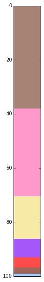

```python
depth = 0
list_of_int = []
for i in striplog.top:
    list_of_int.append(Interval(depth, depth+i[1], components=[i[0]]))
    depth += i[1]
t = Striplog(list_of_int)
t.plot(legend)
```

### Plot

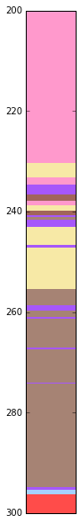

```python
striplog.plot(legend)
```

### Slice and iterate

Again, the object is iterable.

```python
print striplog[-1].primary.summary()
```

```
Volcanic
```

```python
len(striplog)
```

```
26
```

```python
np.array([d.top for d in striplog[5:13]])
```

```
array([ 237.91102515,  238.72340426,  239.8065764 ,  240.77369439,
        241.12185687,  241.70212766,  243.09477756,  246.65377176])
```

You can even index into it with an interable, like a list of indices.

```python
indices = [2,4,6]
print striplog[indices]
```

```
top: 233.268858801, base: 234.700193424, description: '', components: [Rock(colour='', lithology='anhydrite', grainsize='')]
top: 236.595744681, base: 237.911025145, description: '', components: [Rock(colour='red', lithology='siltstone', grainsize='')]
top: 238.723404255, base: 239.806576402, description: '', components: [Rock(colour='grey', lithology='sandstone', grainsize='vf-f')]
```

### Find words in descriptions

This results in a new Striplog, contianing only the intervals requested.

```python
striplog.find('sandstone')
```

```
Striplog(4 Intervals, start=230.328820116, stop=255.435203095)
```

```python
striplog.find('sandstone').top
```

```
[(Rock(colour='grey', lithology='sandstone', grainsize='vf-f'),
  15.783365570599585)]
```

```python
striplog.find('sandstone').cum
```

```
15.783365570599585
```

```python
print striplog.find('sandstone')
```

```
top: 230.328820116, base: 233.268858801, description: '', components: [Rock(colour='grey', lithology='sandstone', grainsize='vf-f')]
top: 238.723404255, base: 239.806576402, description: '', components: [Rock(colour='grey', lithology='sandstone', grainsize='vf-f')]
top: 243.094777563, base: 246.65377176, description: '', components: [Rock(colour='grey', lithology='sandstone', grainsize='vf-f')]
top: 247.234042553, base: 255.435203095, description: '', components: [Rock(colour='grey', lithology='sandstone', grainsize='vf-f')]
```

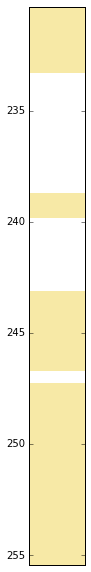

```python
striplog.find('sandstone').plot(legend)
```

Let's ask for the rock we just found by seaching.

```python
rock = striplog.find('sandstone')[1].components[0]
rock
```

```
Rock(colour='grey', lithology='sandstone', grainsize='vf-f')
```

We can also search for a rock...

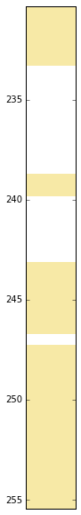

```python
striplog.find(rock).plot(legend)
```

```python
rock in striplog
```

```
True
```

```python
for r in reversed(striplog):
    print r
```

```
top: 296.286266925, base: 300.0, description: '', components: [Rock(colour='', lithology='volcanic', grainsize='')]
top: 295.396518375, base: 296.286266925, description: '', components: [Rock(colour='', lithology='limestone', grainsize='')]
top: 294.816247582, base: 295.396518375, description: '', components: [Rock(colour='', lithology='dolomite', grainsize='')]
top: 274.313346228, base: 294.816247582, description: '', components: [Rock(colour='grey', lithology='siltstone', grainsize='')]
top: 274.003868472, base: 274.313346228, description: '', components: [Rock(colour='', lithology='dolomite', grainsize='')]
top: 267.350096712, base: 274.003868472, description: '', components: [Rock(colour='grey', lithology='siltstone', grainsize='')]
top: 267.040618956, base: 267.350096712, description: '', components: [Rock(colour='', lithology='dolomite', grainsize='')]
top: 261.353965184, base: 267.040618956, description: '', components: [Rock(colour='grey', lithology='siltstone', grainsize='')]
top: 260.967117988, base: 261.353965184, description: '', components: [Rock(colour='', lithology='dolomite', grainsize='')]
top: 259.729206963, base: 260.967117988, description: '', components: [Rock(colour='grey', lithology='siltstone', grainsize='')]
top: 258.723404255, base: 259.729206963, description: '', components: [Rock(colour='', lithology='dolomite', grainsize='')]
top: 255.435203095, base: 258.723404255, description: '', components: [Rock(colour='grey', lithology='siltstone', grainsize='')]
top: 247.234042553, base: 255.435203095, description: '', components: [Rock(colour='grey', lithology='sandstone', grainsize='vf-f')]
top: 246.65377176, base: 247.234042553, description: '', components: [Rock(colour='', lithology='dolomite', grainsize='')]
top: 243.094777563, base: 246.65377176, description: '', components: [Rock(colour='grey', lithology='sandstone', grainsize='vf-f')]
top: 241.70212766, base: 243.094777563, description: '', components: [Rock(colour='', lithology='dolomite', grainsize='')]
top: 241.121856867, base: 241.70212766, description: '', components: [Rock(colour='grey', lithology='siltstone', grainsize='')]
top: 240.773694391, base: 241.121856867, description: '', components: [Rock(colour='', lithology='dolomite', grainsize='')]
top: 239.806576402, base: 240.773694391, description: '', components: [Rock(colour='red', lithology='siltstone', grainsize='')]
top: 238.723404255, base: 239.806576402, description: '', components: [Rock(colour='grey', lithology='sandstone', grainsize='vf-f')]
top: 237.911025145, base: 238.723404255, description: '', components: [Rock(colour='', lithology='anhydrite', grainsize='')]
top: 236.595744681, base: 237.911025145, description: '', components: [Rock(colour='red', lithology='siltstone', grainsize='')]
top: 234.700193424, base: 236.595744681, description: '', components: [Rock(colour='', lithology='dolomite', grainsize='')]
top: 233.268858801, base: 234.700193424, description: '', components: [Rock(colour='', lithology='anhydrite', grainsize='')]
top: 230.328820116, base: 233.268858801, description: '', components: [Rock(colour='grey', lithology='sandstone', grainsize='vf-f')]
top: 200.0, base: 230.328820116, description: '', components: [Rock(colour='', lithology='anhydrite', grainsize='')]
```

```python
striplog[1:3]
```

```
Striplog(2 Intervals, start=230.328820116, stop=234.700193424)
```

```python
striplog[-3:]
```

```
Striplog(3 Intervals, start=294.816247582, stop=300.0)
```

```python
iv = Interval(top=300, base=350, description='', components=[rock, rock2])
new = striplog[-3:-1] + Striplog([iv])
new
```

```
Striplog(3 Intervals, start=294.816247582, stop=350.0)
```

```python
# Make descriptions if we don't have them
# for iv in s:
#     setattr(iv, 'description', iv.primary.summary())
```

### Read or write CSV or LAS3

```python
print striplog.to_las3()
```

```
~Lithology_Parameter
LITH .   Striplog         : Lithology source          {S}
LITHD.   MD               : Lithology depth reference {S}

~Lithology_Definition
LITHT.M                   : Lithology top depth       {F}
LITHB.M                   : Lithology base depth      {F}
LITHN.                    : Lithology name            {S}

~Lithology_Data | Lithology_Definition
  200.000,  230.329,  Anhydrite
  230.329,  233.269,  Grey vf-f sandstone
  233.269,  234.700,  Anhydrite
  234.700,  236.596,  Dolomite
  236.596,  237.911,  Red siltstone
  237.911,  238.723,  Anhydrite
  238.723,  239.807,  Grey vf-f sandstone
  239.807,  240.774,  Red siltstone
  240.774,  241.122,  Dolomite
  241.122,  241.702,  Grey siltstone
  241.702,  243.095,  Dolomite
  243.095,  246.654,  Grey vf-f sandstone
  246.654,  247.234,  Dolomite
  247.234,  255.435,  Grey vf-f sandstone
  255.435,  258.723,  Grey siltstone
  258.723,  259.729,  Dolomite
  259.729,  260.967,  Grey siltstone
  260.967,  261.354,  Dolomite
  261.354,  267.041,  Grey siltstone
  267.041,  267.350,  Dolomite
  267.350,  274.004,  Grey siltstone
  274.004,  274.313,  Dolomite
  274.313,  294.816,  Grey siltstone
  294.816,  295.397,  Dolomite
  295.397,  296.286,  Limestone
  296.286,  300.000,  Volcanic
```

```python
csv_string = """  200.000,  230.329,  Anhydrite
  230.329,  233.269,  Grey vf-f sandstone
  233.269,  234.700,  Anhydrite
  234.700,  236.596,  Dolomite
  236.596,  237.911,  Red siltstone
  237.911,  238.723,  Anhydrite
  238.723,  239.807,  Grey vf-f sandstone
  239.807,  240.774,  Red siltstone
  240.774,  241.122,  Dolomite
  241.122,  241.702,  Grey siltstone
  241.702,  243.095,  Dolomite
  243.095,  246.654,  Grey vf-f sandstone
  246.654,  247.234,  Dolomite
  247.234,  255.435,  Grey vf-f sandstone
  255.435,  258.723,  Grey siltstone
  258.723,  259.729,  Dolomite
  259.729,  260.967,  Grey siltstone
  260.967,  261.354,  Dolomite
  261.354,  267.041,  Grey siltstone
  267.041,  267.350,  Dolomite
  267.350,  274.004,  Grey siltstone
  274.004,  274.313,  Dolomite
  274.313,  294.816,  Grey siltstone
  294.816,  295.397,  Dolomite
  295.397,  296.286,  Limestone
  296.286,  300.000,  Volcanic
"""
```

```python
strip2 = Striplog.from_csv(csv_string, lexicon=lexicon)
```

```
rock.py:102: UserWarning: No lithology in lexicon matching 'Volcanic'
  warnings.warn(w)
```

Notice the warning about a missing term in the lexicon.

```python
Rock.from_text('Volcanic', lexicon)
```

```
rock.py:102: UserWarning: No lithology in lexicon matching 'Volcanic'
  warnings.warn(w)
```

```python
Rock.from_text('Grey vf-f sandstone', lexicon)
```

```
Rock(colour='grey', lithology='sandstone', grainsize='vf-f')
```

```python
las3 = """~Lithology_Parameter
LITH .                    : Lithology source          {S}
LITHD.   MD               : Lithology depth reference {S}

~Lithology_Definition
LITHT.M                   : Lithology top depth       {F}
LITHB.M                   : Lithology base depth      {F}
LITHN.                    : Lithology name            {S}

~Lithology_Data | Lithology_Definition
  200.000,  230.329,  Anhydrite
  230.329,  233.269,  Grey vf-f sandstone
  233.269,  234.700,  Anhydrite
  234.700,  236.596,  Dolomite
  236.596,  237.911,  Red siltstone
  237.911,  238.723,  Anhydrite
  238.723,  239.807,  Grey vf-f sandstone
  239.807,  240.774,  Red siltstone
  240.774,  241.122,  Dolomite
  241.122,  241.702,  Grey siltstone
  241.702,  243.095,  Dolomite
  243.095,  246.654,  Grey vf-f sandstone
  246.654,  247.234,  Dolomite
  247.234,  255.435,  Grey vf-f sandstone
  255.435,  258.723,  Grey siltstone
  258.723,  259.729,  Dolomite
  259.729,  260.967,  Grey siltstone
  260.967,  261.354,  Dolomite
  261.354,  267.041,  Grey siltstone
  267.041,  267.350,  Dolomite
  267.350,  274.004,  Grey siltstone
  274.004,  274.313,  Dolomite
  274.313,  294.816,  Grey siltstone
  294.816,  295.397,  Dolomite
  295.397,  296.286,  Limestone
  296.286,  300.000,  Volcanic
"""
```

```python
strip3 = Striplog.from_las3(las3, lexicon)
strip3
```

```
Striplog(26 Intervals, start=200.0, stop=300.0)
```

```python
strip3.top
```

```
[(Rock(colour='grey', lithology='siltstone'), 37.94999999999999),
 (Rock(lithology='anhydrite'), 32.572),
 (Rock(colour='grey', lithology='sandstone', grainsize='vf-f'),
  15.783999999999963),
 (Rock(lithology='dolomite'), 6.809000000000026),
 (None, 3.7139999999999986),
 (Rock(colour='red', lithology='siltstone'), 2.2820000000000107),
 (Rock(lithology='limestone'), 0.88900000000001)]
```

## Lexicon

This probably does not need to be an object, because we only define it once. It's almost a constant.

```python
lexicon = { 'lithologies':[r'overburden', r'sandstone', r'siltstone', r'shale', r'mudstone',
                           r'limestone', r'dolomite',
                           r'salt', r'halite', r'anhydrite', r'gypsum', r'sylvite',
                           r'clay', r'mud', r'silt', r'sand', r'gravel', r'boulders',
                           ],
            'amounts': [r'streaks?', r'veins?', r'stringers?', r'interbed(?:s|ded)?',
                        r'blotch(?:es)?', r'bands?', r'fragments?', r'impurit(?:y|ies)',
                        r'minor', r'some', r'abundant', r'rare', r'flakes?',
                        r'[-\.\d]+%'
                       ],
            'grainsizes': [r'vf', r'f', r'm', r'c', r'vc',
                           r'very fine', r'fine', r'medium', r'coarse', r'very coarse',
                           r'v fine', r'med', r'med.', r'v coarse',
                           r'grains?', r'granules?', r'pebbles?', r'cobbles?', r'boulders?',
                          ],
            'colours': [r"red(?:dish)?",
                        r"gray(?:ish)?",
                        r"grey(?:ish)?",
                        r"black(?:ish)?",
                        r"whit(?:e|ish)",
                        r"blu(?:e|ish)",
                        r"purpl(?:e|ish)",
                        r"yellow(?:ish)?",
                        r"green(?:ish)?",
                        r"brown(?:ish)?",
                        r"light", "dark",
                        r"sandy"
                        ],
            'synonyms': {'Overburden': ['Drift'],
                         'Anhydrite': ['Gypsum'],
                         'Salt': ['Halite', 'Sylvite'],
                        }
            }
```

```python
import json
with open('lexicon.json', 'w') as fp:
    json.dump(lexicon, fp)
```

```python
with open('lexicon.json', 'r') as fp:
    lexicon = json.load(fp)
lexicon
```

```
{u'amounts': [u'streaks?',
  u'veins?',
  u'stringers?',
  u'interbed(?:s|ded)?',
  u'blotch(?:es)?',
  u'bands?',
  u'fragments?',
  u'impurit(?:y|ies)',
  u'minor',
  u'some',
  u'abundant',
  u'rare',
  u'flakes?',
  u'[-\\.\\d]+%'],
 u'colours': [u'red(?:dish)?',
  u'gray(?:ish)?',
  u'grey(?:ish)?',
  u'black(?:ish)?',
  u'whit(?:e|ish)',
  u'blu(?:e|ish)',
  u'purpl(?:e|ish)',
  u'yellow(?:ish)?',
  u'green(?:ish)?',
  u'brown(?:ish)?',
  u'light',
  u'dark',
  u'sandy'],
 u'grainsizes': [u'vf',
  u'f',
  u'm',
  u'c',
  u'vc',
  u'very fine',
  u'fine',
  u'medium',
  u'coarse',
  u'very coarse',
  u'v fine',
  u'med',
  u'med.',
```

[output cut: 12 more lines]

```
  u'dolomite',
  u'salt',
  u'halite',
  u'anhydrite',
  u'gypsum',
  u'sylvite',
  u'clay',
  u'mud',
  u'silt',
  u'sand',
  u'gravel',
  u'boulders'],
 u'synonyms': {u'Anhydrite': [u'Gypsum'],
  u'Overburden': [u'Drift'],
  u'Salt': [u'Halite', u'Sylvite']}}
```